## Data Analysis Of NYPD Shooting Incident

[figure not shown]

**Data Provider: Police Department**  
**Last Updated: April 23, 2024**

<sup>**Import library**</sup>

```r
library(dplyr)
library(tidyverse)
```

```r
library(lubridate)
library(glue)
library(ggplot2)
```

This is the breakdown of every shooting incident that occurred in NYC from 2006 until 2023.

### **Import Data**

```r
NYPD <- read.csv("https://data.cityofnewyork.us/resource/833y-fsy8.csv?$limit=28562")
```

#### NYPD: Maximum number of Shooting incidents

Changing the format of occur_date column in dataset using as.date() function and load date as factor. Total number of shooting incident in the NYPD historic data, transform the dataset to get top five dates when the shooting incidents are maximum.

```r
NYPD_1 <- subset(NYPD, select = -c(incident_key,occur_date))
incident_key<- NYPD$incident_key
occur_date <- as.Date(NYPD$occur_date)
occur_date<- factor(occur_date)
head(date)
```

```
##
## 1 function (x)
## 2 {
## 3     UseMethod("date")
## 4 }
```

```r
NYPD_data <- data.frame(incident_key,occur_date, NYPD_1)
NYPD_by_date <- NYPD_data %>% group_by(occur_date) %>%
  summarise(total_count=n(),
            .groups = 'drop')

NYPD_by_date<-NYPD_by_date%>%top_n(5)
NYPD_by_date
```

```
## # A tibble: 6 × 2
##   occur_date total_count
##   <fct>            <int>
## 1 2006-09-04          25
## 2 2007-08-11          26
## 3 2011-09-04          31
## 4 2020-07-05          47
## 5 2020-07-26          29
## 6 2022-08-27          25
```

Select columns for analysis using select() function

```r
NYPD_data%>% select(incident_key,occur_date,occur_time,boro,loc_of_occur_desc,precinct,jurisdiction_code,loc_classfctn_desc,location_desc,statistical_murder_flag,perp_age_group,perp_sex,perp_race,vic_age_group,vic_sex,vic_race) %>% head(5)
```

```
##   incident_key occur_date occur_time     boro loc_of_occur_desc precinct
## 1    279683077 2023-12-29   03:43:00   QUEENS            INSIDE      113
## 2    279709792 2023-12-29   21:22:00 BROOKLYN           OUTSIDE       75
## 3    279758069 2023-12-29   18:40:00    BRONX           OUTSIDE       40
## 4    279609499 2023-12-27   19:47:00    BRONX           OUTSIDE       42
## 5    279500313 2023-12-26   05:09:00 BROOKLYN           OUTSIDE       73
##   jurisdiction_code loc_classfctn_desc    location_desc statistical_murder_flag
## 1                 0         COMMERCIAL RESTAURANT/DINER                   false
## 2                 0             STREET           (null)                   false
## 3                 0             STREET           (null)                   false
## 4                 0             STREET           (null)                   false
## 5                 0             STREET           (null)                   false
##   perp_age_group perp_sex perp_race vic_age_group vic_sex       vic_race
## 1         (null)   (null)    (null)         25-44       M          BLACK
## 2          25-44        M     BLACK         25-44       M          BLACK
## 3         (null)   (null)    (null)           65+       M BLACK HISPANIC
## 4         (null)   (null)    (null)           <18       M BLACK HISPANIC
## 5         (null)   (null)    (null)         25-44       M          BLACK
```

```r
summary(NYPD_data)
```

```
##   incident_key            occur_date     occur_time            boro
##  Min.   :  9953245   2020-07-05:   47   Length:28562       Length:28562
##  1st Qu.: 65439914   2011-09-04:   31   Class :character   Class :character
##  Median : 92711254   2020-07-26:   29   Mode  :character   Mode  :character
##  Mean   :127405824   2007-08-11:   26
##  3rd Qu.:203131993   2006-09-04:   25
##  Max.   :279758069   2022-08-27:   25
##                      (Other)   :28379
##  loc_of_occur_desc     precinct     jurisdiction_code loc_classfctn_desc
##  Length:28562       Min.   :  1.0   Min.   :0.0000    Length:28562
##  Class :character   1st Qu.: 44.0   1st Qu.:0.0000    Class :character
##  Mode  :character   Median : 67.0   Median :0.0000    Mode  :character
##                     Mean   : 65.5   Mean   :0.3219
##                     3rd Qu.: 81.0   3rd Qu.:0.0000
##                     Max.   :123.0   Max.   :2.0000
##                                     NA's   :2
##  location_desc      statistical_murder_flag perp_age_group
##  Length:28562       Length:28562            Length:28562
##  Class :character   Class :character        Class :character
##  Mode  :character   Mode  :character        Mode  :character
##
##
##
##
##    perp_sex          perp_race         vic_age_group        vic_sex
##  Length:28562       Length:28562       Length:28562       Length:28562
##  Class :character   Class :character   Class :character   Class :character
##  Mode  :character   Mode  :character   Mode  :character   Mode  :character
##
##
##
##
##    vic_race           x_coord_cd        y_coord_cd        latitude
##  Length:28562       Min.   : 914928   Min.   :125757   Min.   :40.51
##  Class :character   1st Qu.:1000068   1st Qu.:182912   1st Qu.:40.67
##  Mode  :character   Median :1007772   Median :194901   Median :40.70
##                     Mean   :1009424   Mean   :208380   Mean   :40.74
##                     3rd Qu.:1016807   3rd Qu.:239814   3rd Qu.:40.82
##                     Max.   :1066815   Max.   :271128   Max.   :40.91
##                                                        NA's   :59
##    longitude      geocoded_column
##  Min.   :-74.25   Length:28562
##  1st Qu.:-73.94   Class :character
##  Median :-73.92   Mode  :character
##  Mean   :-73.91
##  3rd Qu.:-73.88
##  Max.   :-73.70
##  NA's   :59
```

## **Plot**

### plot.1 Data visualization

The plot shows total number of shooting incident take place with respect to each borough in New York City.

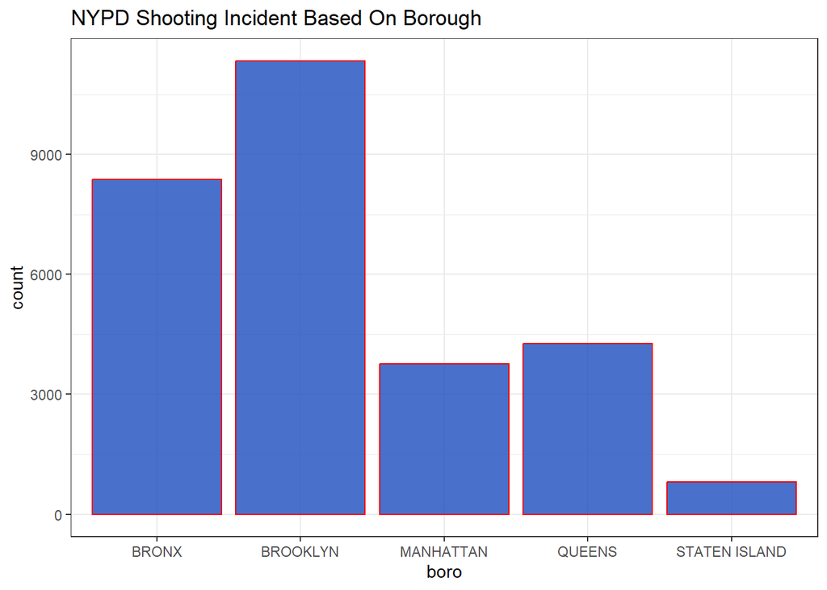

```r
ggplot(NYPD_data,mapping = aes(x = boro))+geom_bar(color = 'red', fill = '#1c4cbd',alpha = 0.8 )+labs(title = "NYPD Shooting Incident Based On Borough")+theme_bw()
```

```r
NYPD_boro <- NYPD_data %>% group_by(boro) %>%
  summarise(total_count=n(),
            .groups = 'drop')
NYPD_boro
```

```
## # A tibble: 5 × 2
##   boro          total_count
##   <chr>               <int>
## 1 BRONX                8376
## 2 BROOKLYN            11346
## 3 MANHATTAN            3762
## 4 QUEENS               4271
## 5 STATEN ISLAND         807
```

### plot.2 Data visualization

This data visualization plot summaries the statistical murder in NYPD shooting Incident.

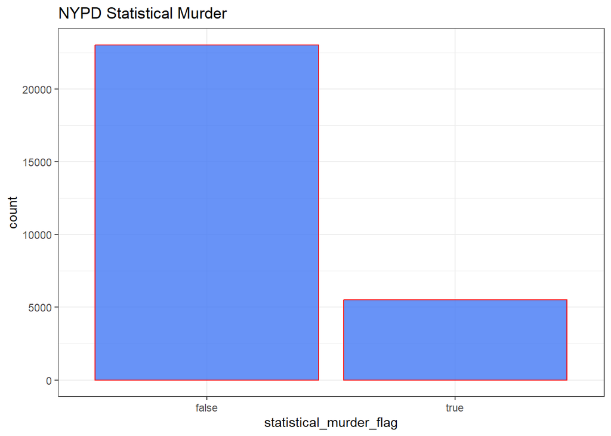

```r
ggplot(NYPD,mapping= aes(x= statistical_murder_flag ))+ geom_bar(color = "red", fill = "#4278f5", alpha = 0.8)+ labs(title = "NYPD Statistical Murder")+theme_bw()
```

```r
NYPD_statistical_murder <- NYPD_data %>% group_by(statistical_murder_flag) %>%
  summarise(total_count=n(),
            .groups = 'drop')
NYPD_statistical_murder
```

```
## # A tibble: 2 × 2
##   statistical_murder_flag total_count
##   <chr>                         <int>
## 1 false                         23036
## 2 true                           5526
```

### plot.3 Data visualization

This data visualization plot summaries Victim race and Perpetrator race in NYPD shooting Incident.

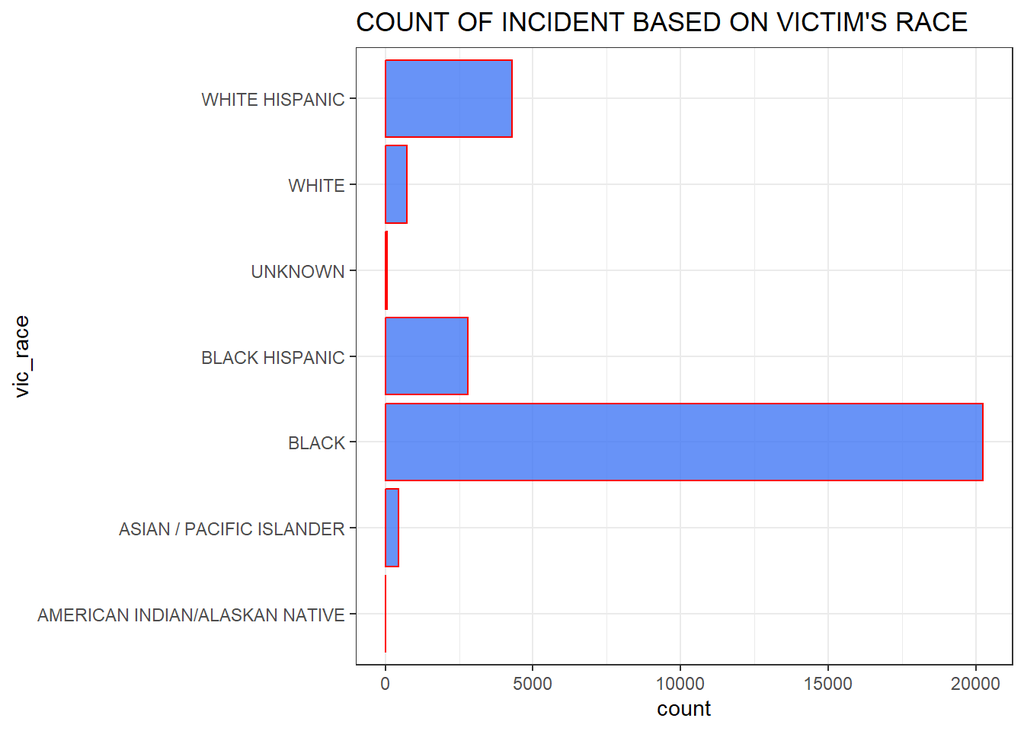

```r
ggplot(NYPD_data,mapping= aes(y= vic_race ))+ geom_bar(color = "red", fill = "#4278f5", alpha = 0.8)+ labs(title = "COUNT OF INCIDENT BASED ON VICTIM'S RACE")+theme_bw()
```

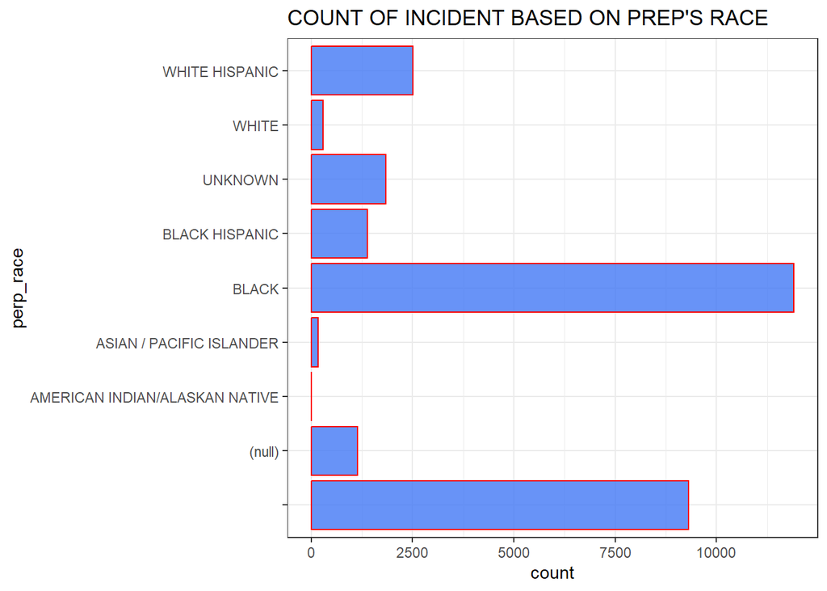

```r
NYPD_Victim_race <- NYPD_data %>% group_by(vic_race) %>%
  summarise(total_count=n(),
            .groups = 'drop')

ggplot(NYPD_data,mapping= aes(y= perp_race ))+ geom_bar(color = "red", fill = "#4278f5", alpha = 0.8)+ labs(title = "COUNT OF INCIDENT BASED ON PREP'S RACE")+theme_bw()
```

```r
NYPD_perpetrator_race <- NYPD_data %>% group_by(perp_race) %>%
  summarise(total_count=n(),
            .groups = 'drop')
# changing column names
colnames(NYPD_Victim_race)[2]<- "VICTIM"
colnames(NYPD_perpetrator_race)[2]<- "PERPETRATOR"
NYPD_Victim_race
```

```
## # A tibble: 7 × 2
##   vic_race                       VICTIM
##   <chr>                           <int>
## 1 AMERICAN INDIAN/ALASKAN NATIVE     11
## 2 ASIAN / PACIFIC ISLANDER          440
## 3 BLACK                           20235
## 4 BLACK HISPANIC                   2795
## 5 UNKNOWN                            70
## 6 WHITE                             728
## 7 WHITE HISPANIC                   4283
```

```r
NYPD_perpetrator_race
```

```
## # A tibble: 9 × 2
##   perp_race                        PERPETRATOR
##   <chr>                                  <int>
## 1 ""                                      9310
## 2 "(null)"                                1141
## 3 "AMERICAN INDIAN/ALASKAN NATIVE"           2
## 4 "ASIAN / PACIFIC ISLANDER"               169
## 5 "BLACK"                                11903
## 6 "BLACK HISPANIC"                        1392
## 7 "UNKNOWN"                               1837
## 8 "WHITE"                                  298
## 9 "WHITE HISPANIC"                        2510
```